# Socio-Economic Characteristics of Conservation Easement Locations

Matt Kuniholm

2025-01-08

## Overview

Conservation easements are legal mechanisms to limit the use of land, typically so that forests, farms or native lands cannot be developed for residential or industrial uses.

This project seeks to understand the extent, distribution, and socio-economic characteristics of conservation easements in the United States in order to identify opportunities to broaden the benefit of conservation easements in more areas.

## Research Questions

1. What is the spatial distribution of conservation easements in the United States?
2. What are the socio-economic characteristics of counties that host conservation easements?
3. What policies or initiatives could increase the extent of conservation easements in the United States?

## Why is this important?

There has been a ‘renewed focus on conservation easements’, as demonstrated by Executive Order No. 14,008, *Executive Order on Tackling the Climate Crisis at Home and Abroad*, on January 27, 2021 [available here](https://www.whitehouse.gov/briefing-room/presidential-actions/2021/01/27/executive-order-on-tackling-the-climate-crisis-at-home-and-abroad/), recent research [here, for example](https://wildlife.onlinelibrary.wiley.com/doi/full/10.1002/wsb.1415), and new funding sources (e.g. [this one from USDA](https://www.nrcs.usda.gov/conservation-basics/conservation-by-state/montana/news/usda-announces-new-fiscal-year-2025-funding)).

Despite the positive press, information about the socio-economic and environmental impact of conservation easements is focused heavily on providing management guidelines for landowners or tax and financial strategies aligned with donations to land trusts and NGOs. Available research is often site-specific or focused on narrow thematic interests. Broad analyses are therefore helpful to understand trends in conservation easements and how such trends are aligned with socio-economic parameters that may help or hinder the implementation of conservation easements.

This project seeks to highlight the datasets and analytical methods that can be used to further explore conservation easements, identify trends, and suggest opportunities to improve the socio-economic impact of conservation easements throughout the United States.

## Data

Data for this project includes:

- National Conservation Easement Database https://www.conservationeasement.us/
- U.S. Census Bureau, U.S. Department of Commerce. “Selected Population Profile in the United States.” American Community Survey, ACS 1-Year Estimates Selected Population Profiles, Table S0201, 2023 https://data.census.gov/

The two primary data-sets above include the spatial location of conservation easements in the United States and a selection of relevant socio-economic data from the United States Census Bureau. The socio-economic dataset could be expanded using census data as needed to include additional themes.

The project utilizes techniques described in the book Analyzing US Census Data: Methods, Maps, and Models in R by Kyle Walker, available here: https://walker-data.com/census-r/index.html.

## Data Processing

First, inspect and clean the NCED data in excel. To facilitate later joins, add columns to convert the state abbreviations to the full name and a column with both county and state. You can do this in R as well, but it’s good to double check and clean data in Excel to keep things simple for this project. To do so, add a table of counties and states and then use the VLOOKUP function to convert the abbreviations, and the CONCAT function to unite the country and states, using a “, County” delimiter.

Next, load the NCED data into R, and do the same for the other datasets described later on in this project.

```r
nced <- read.csv("NCED2.csv")
public_land <- read.csv("public_land.csv")
```

For all other data, this project uses the tidyverse and tidycensus packages in R to access, process and analyze census data. Note that the tidycensus package requires an API which can be setup here: https://api.census.gov/data/key_signup.html

```r
install.packages("tidyverse")
install.packages("tidycensus")
install.packages("tigris")
install.packages("patchwork")
install.packages("ggpubr")
install.packages("viridis")

library("tidyverse")
library("tidycensus")
library("tigris")
library("patchwork")
library("ggpubr")
library("viridis")
# census_api_key("YOUR KEY GOES HERE", install = TRUE)
options(tigris_use_cache = TRUE)
```

## Analysis

Where are conservation easements located?

Basic answers to this question can be found using the NCED interactive viewer [here](https://site.tplgis.org/NCED/planningapp/). With a little more effort, a quick visualization can be created using Tableau, as shown [here](https://public.tableau.com/views/SummaryofNationalConservationEasementDatabase/Dashboard1?:language=en-US&:sid=&:redirect=auth&:display_count=n&:origin=viz_share_link). While these are helpful visualizations, they have limited value for analyzing the data to answer the research questions.

Instead, lets summarize the NCED data into a list of states and/or counties with conservation easements. Use the count (or equivalent n() function) to find the number of easements and the total area of easements in each state or county. This can be visualized in two charts to show the same data included in the combined bar and line chart in the Tableau visualization above.

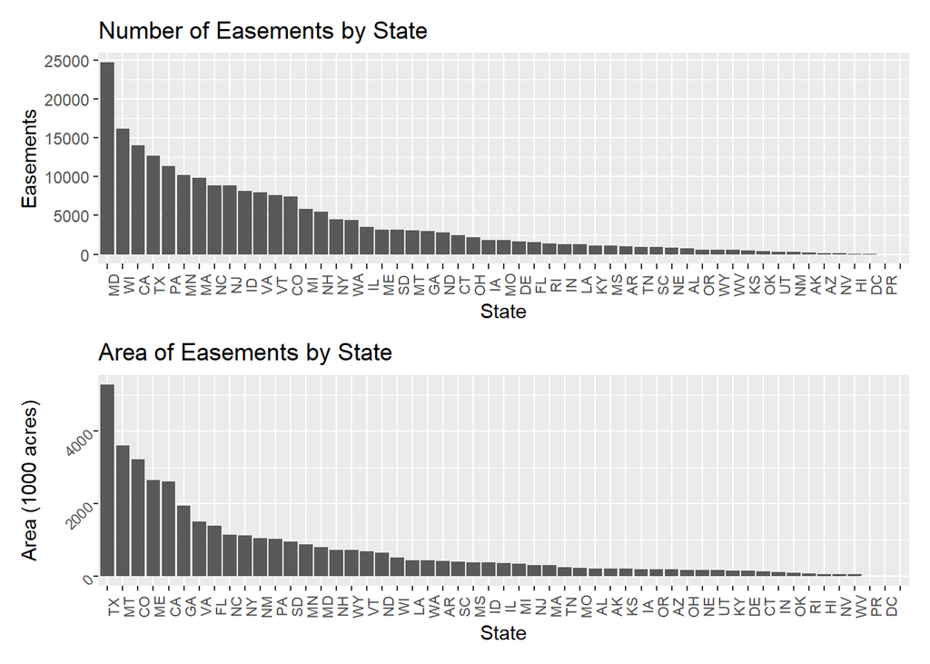

```r
nced_state <- nced %>%
  group_by(state) %>%
  summarize(
    easements = n(),
    area = sum(as.numeric(gis_acres)),
    mean_area = mean(as.numeric(gis_acres)))

p_state_count <- ggplot(nced_state, aes(x=reorder(state, -easements)))+
  geom_bar(aes(y=easements),stat = "identity")+
  theme(axis.text.x = element_text(size=8, angle=90))+
  xlab("State")+ ylab("Easements")+
  ggtitle("Number of Easements by State")

p_state_sum <- ggplot(nced_state, aes(x=reorder(state, -area)))+
  geom_bar(aes(y=area/1000),stat = "identity")+
  theme(
    axis.text.x = element_text(size=8, angle=90),
    axis.text.y = element_text(size=8, angle=45))+
  xlab("State") +ylab("Area (1000 acres)")+
  ggtitle("Area of Easements by State")

p_state_count / p_state_sum
```

What are the socio-economic characteristics of counties that host easements?

This question can be answered in many ways, ranging from summary statistics to inferential statistics and analysis. For demonstration, we will first assess an example summary statistic comparing counties with and without conservation easements. This process could be used for any variables of interest to assess broad dynamics potentially associated between the presence of conservation easements and county-level demographic characteristics, such as income, race, age, and opportunity zones.

We will then assess several additional characteristics that may be associated with conservation easements. These include:

- the percentage of public land in the county,
- the most recent national election result,
- and the median home price in the county.

For the summary statistics, we will use the most recent national census data (2020), accessed using the tidycensus package in R. To search for variables that match our research interests in the latest census data, use the load_variables() function to call a list of themes and variables.

```r
available_variables <- load_variables(year = 2020, dataset = "acs5")
head(available_variables)
```

```
## # A tibble: 6 × 4
##   name        label                                   concept          geography
##   <chr>       <chr>                                   <chr>            <chr>
## 1 B01001A_001 Estimate!!Total:                        SEX BY AGE (WHI… tract
## 2 B01001A_002 Estimate!!Total:!!Male:                 SEX BY AGE (WHI… tract
## 3 B01001A_003 Estimate!!Total:!!Male:!!Under 5 years  SEX BY AGE (WHI… tract
## 4 B01001A_004 Estimate!!Total:!!Male:!!5 to 9 years   SEX BY AGE (WHI… tract
## 5 B01001A_005 Estimate!!Total:!!Male:!!10 to 14 years SEX BY AGE (WHI… tract
## 6 B01001A_006 Estimate!!Total:!!Male:!!15 to 17 years SEX BY AGE (WHI… tract
```

Next we will retrieve data for two variables of interest for all counties in the US: median age and median income.

```r
median_age <- get_acs(
  geography = "county",
  variables = "B01002_001",
  year = 2020,
  geometry = TRUE
)

median_income <- get_acs(
  geography = "county",
  variables = "B19013_001",
  year = 2020,
  geometry = TRUE
)
```

Now that we have the NCED data and the two variables of interest from the US census, we can combine, filter and summarize them.

First, lets combine the NCED and census data to assess our variables of interest. Use a left join to add the NCED summary to the median age table from the ACS 2020, using “county, state” as the primary key (renamed “NAME”).

```r
nced_county <- nced %>%
  group_by(county_state) %>%
  summarize(
    easements = n(),
    area = sum(as.numeric(gis_acres)),
    mean_area = mean(as.numeric(gis_acres)))

nced_for_join <- rename(nced_county, NAME = county_state)

nced_median_age <- median_age %>%
  left_join(nced_for_join)
```

Next, lets visualize the data with a simple x-y scatter plot.

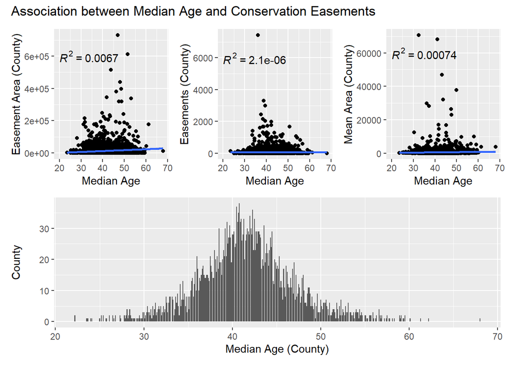

```r
p_age_area <- ggplot(nced_median_age, aes(estimate, area))+
  geom_point()+
  xlab("Median Age")+
  ylab("Easement Area (County)")+
  stat_cor(aes(label=..rr.label..), label.x=20, label.y=600000)+
  geom_smooth(method = "lm")+
  theme(base_size=4)

p_age_easements <- ggplot(nced_median_age, aes(estimate, easements))+
  geom_point()+
  xlab("Median Age")+
  ylab("Easements (County)")+
  stat_cor(aes(label=..rr.label..), label.x=20, label.y=6000)+
  geom_smooth(method = "lm")+
  theme(base_size=4)

p_age_average <- ggplot(nced_median_age, aes(estimate, mean_area))+
  geom_point()+
  xlab("Median Age")+
  ylab("Mean Area (County)")+
  stat_cor(aes(label=..rr.label..), label.x=20, label.y=60000)+
  geom_smooth(method = "lm")+
  theme(base_size=4)

p_age_bar <- ggplot(nced_median_age, aes(estimate))+
  geom_bar()+
  xlab("Median Age (County)")+
  ylab("County")

age_plots <- (p_age_area | p_age_easements | p_age_average) / p_age_bar
age_plots + plot_annotation(
 title = 'Association between Median Age and Conservation Easements'
)
```

While the easement area appears slightly more correlated to median age than either the number of easements or the mean area of easements by county, none of these variables are statistically significant.

We can do the same analysis for any other variable of interest. Lets see if median income by county has greater relevance than median age by repeating the same steps as above to join and visualize the data.

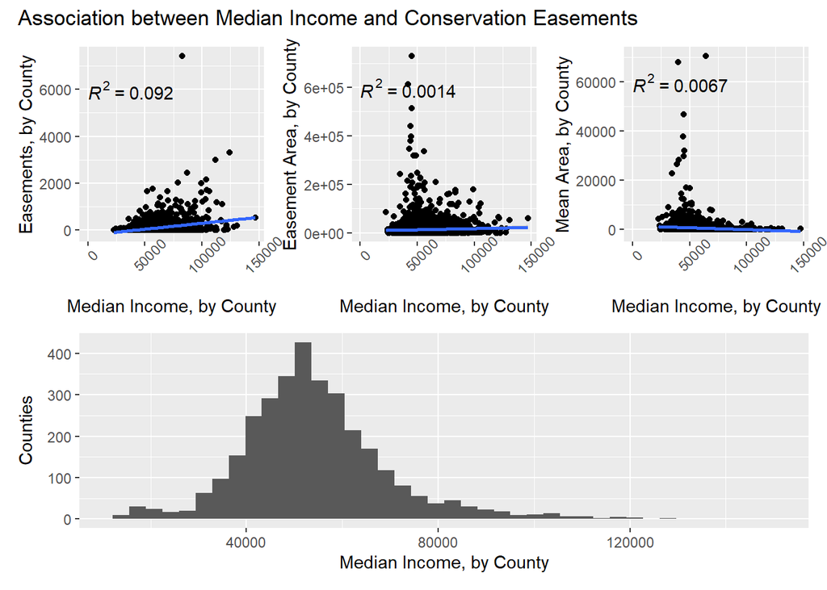

```r
nced_county <- nced %>%
  group_by(county_state) %>%
  summarize(
    easements = n(),
    area = sum(as.numeric(gis_acres)),
    mean_area = mean(as.numeric(gis_acres)))

nced_for_join <- rename(nced_county, NAME = county_state)

nced_median_income <- median_income %>%
  left_join(nced_for_join)

p_income_area <- ggplot(nced_median_income, aes(estimate, area))+
  geom_point()+
  xlab("Median Income, by County")+
  ylab("Easement Area, by County")+
  stat_cor(aes(label=..rr.label..), label.x=20, label.y=600000)+
  geom_smooth(method = "lm")+
  theme(base_size=4)+
  theme(axis.text.x = element_text(angle=45))

p_income_easements <- ggplot(nced_median_income, aes(estimate, easements))+
  geom_point()+
  xlab("Median Income, by County")+
  ylab("Easements, by County")+
  stat_cor(aes(label=..rr.label..), label.x=20, label.y=6000)+
  geom_smooth(method = "lm")+
  theme(base_size=4)+
  theme(axis.text.x = element_text(angle=45))

p_income_average <- ggplot(nced_median_income, aes(estimate, mean_area))+
  geom_point()+
  xlab("Median Income, by County")+
  ylab("Mean Area, by County")+
  stat_cor(aes(label=..rr.label..), label.x=20, label.y=60000)+
  geom_smooth(method = "lm")+
  theme(base_size=2)+
  theme(axis.text.x = element_text(angle=45))

p_income_bar <- ggplot(nced_median_income, aes(x=estimate))+
  geom_histogram(bins = 40)+
  xlab("Median Income, by County")+
  ylab("Counties")

income_plots <- (p_income_easements | p_income_area | p_income_average) / p_income_bar
income_plots + plot_annotation(
 title = 'Association between Median Income and Conservation Easements'
)
```

The number of easements per county has the highest correlation of the three variables in the chart above, but this is still insignificant for our analysis. Lets add an additional data table to see if the percentage of public land by state is associated with the easement data. To do so, load the new data table called “public_land” and run the same analysis.

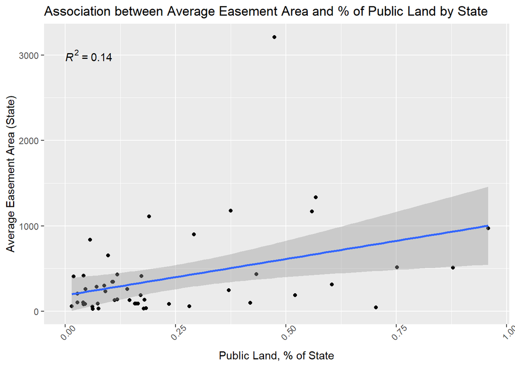

```r
nced_for_join2 <- rename(nced_state, State = state)

nced_public <- public_land %>%
  left_join(nced_for_join2)

p_public_land <- ggplot(nced_public, aes(public, mean_area))+
  geom_point()+
  xlab("Public Land, % of State")+
  ylab("Average Easement Area (State)")+
  stat_cor(aes(label=..rr.label..), label.x=0, label.y=3000)+
  geom_smooth(method = "lm")+
  theme(base_size=4)+
  theme(axis.text.x = element_text(angle=45))+
  labs(title = "Association between Average Easement Area and % of Public Land by State")

p_public_land
```

We’re now finding a bit more correlation, but still not a statistically significant variable. Based on what we learned from the amount of public land by state, lets try something that may be a bit more directly relevant: political party by state. We’ll use data from the Cook Political Report, available [here](https://www.cookpolitical.com/vote-tracker/2020/electoral-college). Load the data from a .csv in the same way as the NCED data, join it with the NCED data, and create a boxplot to visualize the difference between states that voted for each political party in the last election.

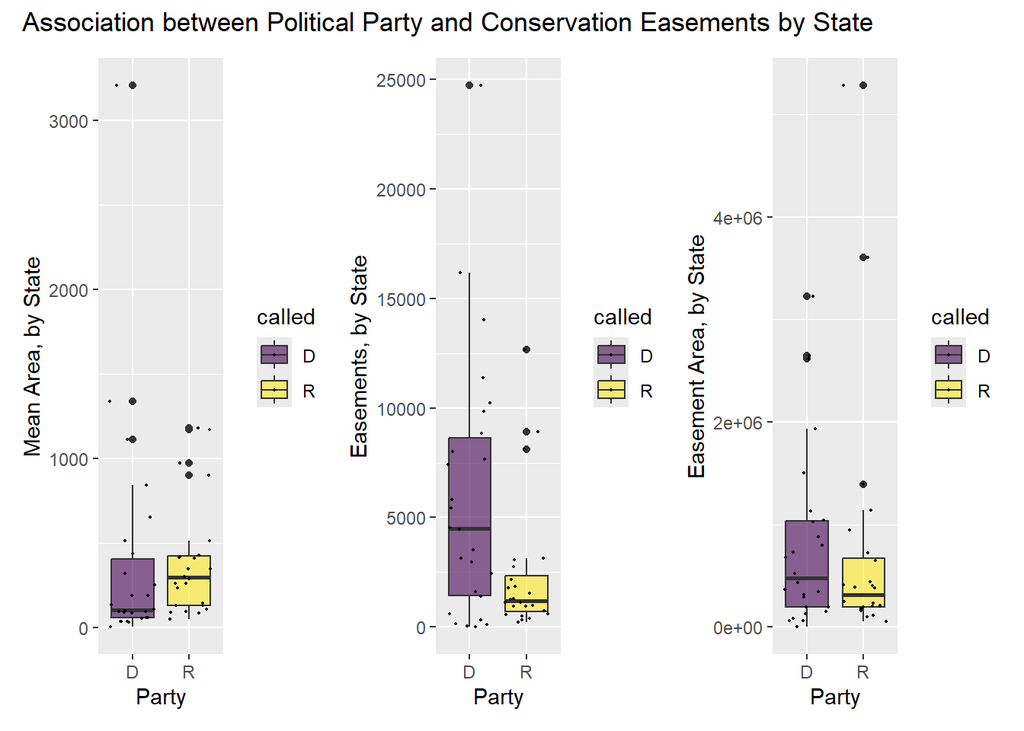

```r
party <- read.csv("vote.csv")
nced_for_join2 <- rename(nced_state, stateid = state)

nced_party <- party %>%
  left_join(nced_for_join2, join_by(stateid))

p_party1 <- ggplot(nced_party, aes(x=called, y=mean_area, fill = called))+
  geom_boxplot()+
  scale_fill_viridis(discrete = TRUE, alpha=0.6)+
  geom_jitter(color="black", size=0.4, alpha=0.9)+
  xlab("Party")+
  ylab("Mean Area, by State")

p_party2 <- ggplot(nced_party, aes(x=called, y=easements, fill = called))+
  geom_boxplot()+
  scale_fill_viridis(discrete = TRUE, alpha=0.6)+
  geom_jitter(color="black", size=0.4, alpha=0.9)+
  xlab("Party")+
  ylab("Easements, by State")

p_party3 <- ggplot(nced_party, aes(x=called, y=area, fill = called))+
  geom_boxplot()+
  scale_fill_viridis(discrete = TRUE, alpha=0.6)+
  geom_jitter(color="black", size=0.4, alpha=0.9)+
  xlab("Party")+
  ylab("Easement Area, by State")

party_plots <- (p_party1 | p_party2 | p_party3)
party_plots + plot_annotation(
 title = 'Association between Political Party and Conservation Easements by State'
)
```

Now we’re seeing some clear differences in the data. While the mean area and total easement area appear to be similar, and potentially skewed by outliers, there appears to be a clear distinction between the number of easements by state depending on which party won the last election. As a final step, lets use a Student’s t-test to analyze the statistical significance of that difference. To do so, run the following:

```r
t.test(easements ~ called, data = nced_party, var.equal = TRUE)
```

```
##
##  Two Sample t-test
##
## data:  easements by called
## t = 2.6421, df = 48, p-value = 0.01109
## alternative hypothesis: true difference in means between group D and group R is not equal to 0
## 95 percent confidence interval:
##   855.5966 6303.9354
## sample estimates:
## mean in group D mean in group R
##        5957.808        2378.042
```

Based on a p-value of 0.01109 we can conclude that there is a statistically significant difference between the number of easements in states based on which party won the last election.

## Discussion

Analyzing the socio-economic characteristics of states and counties where conservation easements are located helps us answer the last research question for this project:

-What policies or initiatives could increase the extent of conservation easements in the United States?

Using the census data compared to the location and extent of conservation easements, we were able to rule out a few potential explanatory themes. The data shows that income and age, two potential parameters whicih policy or conservation initiatives could target, are not likely to be a significant factor for increasing the number or easements or area conserved. However, several insights can be derived for further testing, including whether areas with higher median age and higher income are correlated with trends in conservation easments, perhaps when combined with a third variable such as ecological region.

Through a process of exploratory data analysis, we then tested a few additional themes that turned out to have a higher correlation with the location and extent of conservation easements. The analysis suggests that the following two themes have the highest correlation with the number and extent of conservation easements in the United States:

- Political party is correlated with the total number of easements by state, and
- Geographic factors such as total state area, ecoregion, and land use and land cover type are likely to be more correlated with conservation easement area than demographic factors tested in this analysis.

## Recommendations

This analysis identified several topics where further research could help formulate policies or intiatives to increase the extent of conservation easements in the United States. Recomendations include:

1. Review the policies that could explain the prevalence of conservation easements in democratic states. The review could focus on the 5-10 states with the most conservation easements, as shown above (MD, WI, CA, TX, PA). This analysis would be even more interesting to focus on strategies used in republican states that have successfully promoted conservation easements, like TX.
2. Extend this analysis to include geographic themes such as ecoregion, land use and land cover type. This will require spatially explicit datasets and analyses but would likely result in more actionable conclusions.

The methods demonstrated in this project can be applied for other themes and datasets to extend this analysis and provide more fine-tuned recommendations for the development of policy and initiatives supporting conservation initiatives.

## Additional Reading

Brown, S. A., Rotman, R. M., Powell, M. A., & Wilhelm Stanis, S. A. (2023). Conservation easements: A tool for preserving wildlife habitat on private lands. Wildlife Society Bulletin, 47(2), e1415.

Fishburn, I. S., Kareiva, P., Gaston, K. J., & Armsworth, P. R. (2009). The growth of easements as a conservation tool. PloS one, 4(3), e4996.

Hagen, S., Nolte, C., Chang, Y., Morgan, S., Boccaletti, G., & Reddy, S. M. (2024). Understanding variation in impacts from private protected areas across regions and protection mechanisms to inform organizational practices. Conservation Biology, 38(2), e14225.

Kiesecker, J. M., Comendant, T., Grandmason, T., Gray, E., Hall, C., Hilsenbeck, R., … & Zankel, M. (2007). Conservation easements in context: a quantitative analysis of their use by The Nature Conservancy. Frontiers in Ecology and the Environment, 5(3), 125-130.

Hagen, S., Nolte, C., Chang, Y., Morgan, S., Boccaletti, G., & Reddy, S. M. (2024). Understanding variation in impacts from private protected areas across regions and protection mechanisms to inform organizational practices. Conservation Biology, 38(2), e14225.

Thompson, J. R., Kalinin, A., Lee, L. G., Pasquarella, V. J., Plisinski, J., & Sims, K. R. (2024). Do working forest easements work for conservation?. Environmental Research Letters, 19(11), 114033.